# W3cubDocs

/Cypress

# invoke

Invoke a function on the previously yielded subject.

> If you want to get a property that is not a function on the previously yielded subject, use `.its()`.

# Syntax

```javascript
.invoke(functionName)
.invoke(options, functionName)
.invoke(functionName, args...)
.invoke(options, functionName, args...)
```

## Usage

**Correct Usage**

```javascript
cy.wrap({ animate: fn }).invoke('animate') // Invoke the 'animate' function
cy.get('.modal').invoke('show')            // Invoke the jQuery 'show' function
```

**Incorrect Usage**

```javascript
cy.invoke('convert')                     // Errors, cannot be chained off 'cy'
cy.wrap({ name: 'Jane' }).invoke('name') // Errors, 'name' is not a function
```

## Arguments

**functionName** *(String, Number)*

Name of function to be invoked.

**options** *(Object)*

Pass in an options object to change the default behavior of `.invoke()`.

| Option | Default | Description |
| --- | --- | --- |
| `log` | `true` | Displays the command in the [Command log](https://docs.cypress.io/guides/core-concepts/test-runner.html#Command-Log) |
| `timeout` | [`defaultCommandTimeout`](https://docs.cypress.io/guides/references/configuration.html#Timeouts) | Time to wait for `.invoke()` to resolve before timing out |

**args…**

Additional arguments to be given to the function call. There is no limit to the number of arguments.

# Examples

## Function

### Assert on a function’s return value

```javascript
const fn = () => {
  return 'bar'
}

cy.wrap({ foo: fn }).invoke('foo').should('eq', 'bar') // true
```

### Use `.invoke()` to test HTML content

> [Check out our example recipe where we use `cy.invoke('text')` to test against HTML content in ‘Bootstrapping your App’](https://docs.cypress.io/examples/examples/recipes.html#Server-Communication)

### Properties that are functions are invoked

In the example below, we use `.invoke()` to force a hidden div to be `'display: block'` so we can interact with its children elements.

```javascript
cy.get('div.container').should('be.hidden') // element is hidden
  .invoke('show') // call jquery method 'show' on the '.container'
  .should('be.visible') // element is visible now
  .find('input') // drill down into a child "input" element
  .type('Cypress is great') // and type text
```

### Use `.invoke('show')` and `.invoke('trigger')`

> [Check out our example recipe where we use `cy.invoke('show')` and `cy.invoke('trigger')` to click an element that is only visible on hover](https://docs.cypress.io/examples/examples/recipes.html#Testing-the-DOM)

## Function with Arguments

### Send specific arguments to the function

```javascript
const fn = (a, b, c) => {
  return a + b + c
}

cy
  .wrap({ sum: fn })
  .invoke('sum', 2, 4, 6)
    .should('be.gt', 10) // true
    .and('be.lt', 20)    // true
```

### Use `cy.invoke('removeAttr', 'target')` to get around new tab

> [Check out our example recipe where we use `cy.invoke('removeAttr', 'target')` to test clicking on a link without opening in a new tab](https://docs.cypress.io/examples/examples/recipes.html#Testing-the-DOM)

### Arguments are automatically forwarded to the function

```javascript
cy
  .get('img').invoke('attr', 'src')
    .should('include', 'myLogo')
```

## Arrays

In the above examples, the subject was an object, but `cy.invoke` also works on arrays and allows using numerical index to pick a function to run.

```javascript
const reverse = (s) => Cypress._.reverse(s)
const double = (n) => n * n

// picks function with index 1 and calls it with argument 4
cy.wrap([reverse, double]).invoke(1, 4).should('eq', 16)
```

## Invoking an async function

In this example we have a little text input field and we invoke an async action which will disable this input field.  
`.invoke()` will then wait until the Promise resolves and only then will continue executing to check if it really has been disabled.

Our input field

```html
<input type="text" name="text" data-cy="my-text-input">
```

The Cypress Test with `cy.invoke()` awaiting the promise:

```javascript
function disableElementAsync (element) {
  return new Promise((resolve) => {
    setTimeout(() => {
      element.disabled = true
      resolve()
    }, 3000)
  })
}

cy.get('[data-cy=my-text-input]').then((textElements) => {
  cy.wrap({ disableElementAsync })
    .invoke('disableElementAsync', textElements[0])
})

// log message appears after 3 seconds
cy.log('after invoke')

// assert UI
cy.get('[data-cy=my-text-input]').should('be.disabled')
```

> For a full example where invoke is used to await async Vuex store actions, visit the recipe: [Vue + Vuex + REST](https://github.com/cypress-io/cypress-example-recipes)

# Notes

## Third Party Plugins

### Using a Kendo DropDown

If you are using `jQuery` then the `jQuery` wrapped elements will automatically have your 3rd party plugins available to be called.

```javascript
cy.get('input').invoke('getKendoDropDownList').then((dropDownList) => {
  // yields the return of $input.getKendoDropDownList()
  return dropDownList.select('apples')
})
```

We can rewrite the previous example in a more terse way and add an assertion.

```javascript
cy
  .get('input')
  .invoke('getKendoDropDownList')
  .invoke('select', 'apples')
  .invoke('val').should('match', /apples/)
```

## Retries

`.invoke()` automatically retries invoking the specified method until the returned value satisfies the attached assertions. The example below passes after 1 second.

[figure not shown]

```javascript
let message = 'hello'
const english = {
  greeting () {
    return message
  }
}

setTimeout(() => {
  message = 'bye'
}, 1000)

// initially the english.greeting() returns "hello" failing the assertion.
// .invoke('greeting') tries again and again until after 1 second
// the returned message becomes "bye" and the assertion passes
cy.wrap(english).invoke('greeting').should('equal', 'bye')
```

# Rules

## Requirements

- `.invoke()` requires being chained off a previous command.

## Assertions

- `.invoke()` will wait for the `function` to exist on the subject before running.
- `.invoke()` will wait for the promise to resolve if the invoked `function` returns a promise.
- `.invoke()` will automatically [retry](https://docs.cypress.io/guides/core-concepts/retry-ability.html) until assertions you've chained all pass.

## Timeouts

- `.invoke()` can time out waiting for assertions you've added to pass.
- `.invoke()` can time out waiting for a promise you've returned to resolve.

# Command Log

*Invoke jQuery show method on element*

```javascript
cy.get('.connectors-div').should('be.hidden')
  .invoke('show').should('be.visible')
```

The commands above will display in the Command Log as:

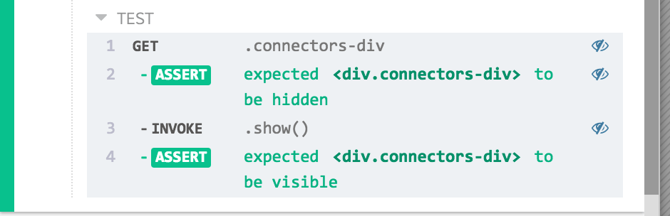

When clicking on `invoke` within the command log, the console outputs the following:

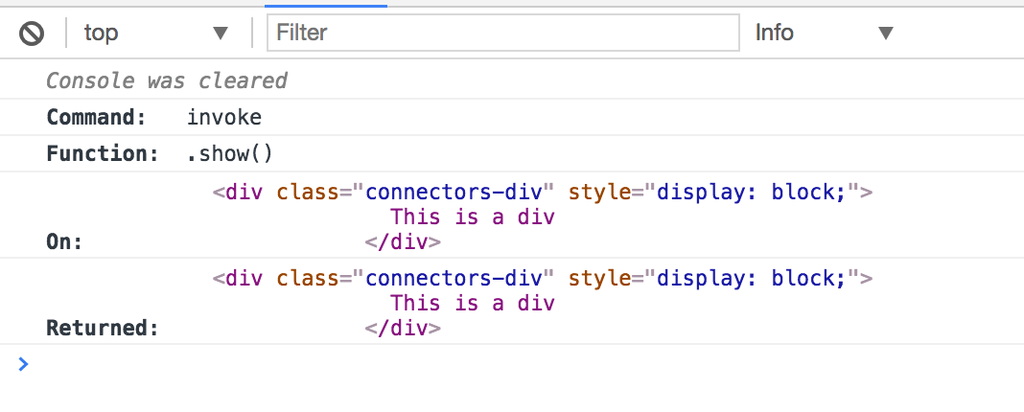

# History

| Version | Changes |
| --- | --- |
| [3.8.0](https://docs.cypress.io/guides/references/changelog.html#3-8-0) | Added support for `options` argument |
| [3.7.0](https://docs.cypress.io/guides/references/changelog.html#3-7-0) | Added support for arguments of type Number for `functionName` |

# See also

- `.its()`
- `.then()`
- `cy.wrap()`

© 2020 Cypress.io  
Licensed under the MIT License.  
https://docs.cypress.io/api/commands/invoke.html